# HNB DigiMedia Map 8: Readability and Accessibility

Analyzing Linguistic Complexity and Its Relationship to Public Attention

Author

HNB DigiMedia Project

Published

January 28, 2026

# 1 Introduction

This document presents **Map 8: Readability and Accessibility Analysis** of the HNB DigiMedia project. The core question driving this analysis is:

> **Is HNB communication accessible to the Croatian public, and does linguistic complexity predict attention?**

## 1.1 Theoretical Motivation

The literature documents concerning trends in central bank communication complexity:

1. **Rising complexity:** FOMC statements reached grade level 18-19 under Yellen versus grade 14 under Greenspan
2. **Clarity-volatility tradeoff:** Bulíř, Čihák, and Jansen (2013) documented an inverse relationship between communication clarity and financial market volatility
3. **Dual complexity:** McMahon and Naylor (2023) distinguish semantic complexity (vocabulary difficulty) from conceptual complexity (idea density)
4. **Public disconnect:** Even the ECB’s 2021 inflation target revision “went largely unnoticed by consumers,” suggesting accessibility barriers

For smaller central banks like HNB, the challenge is compounded by:

- Limited resources for communication simplification
- Need to maintain technical precision for market participants
- Balancing expert and public audiences simultaneously

## 1.2 Readability Framework for Croatian

Standard readability formulas (Flesch-Kincaid, Gunning Fog) are calibrated for English. For Croatian text, we adapt metrics focusing on universal linguistic features:

| Metric | Definition | Interpretation |
| --- | --- | --- |
| Avg Sentence Length | Words per sentence | Higher = more complex |
| Avg Word Length | Characters per word | Higher = more technical vocabulary |
| Long Word Ratio | % words with 7+ characters | Higher = more complex |
| Technical Term Density | Financial/economic terms per 100 words | Higher = more specialized |
| LIX Score | Swedish formula adapted for Slavic languages | Higher = more difficult |

**LIX Formula (Läsbarhetsindex):**
$$LIX = \frac{Words}{Sentences} + \frac{Long Words \times 100}{Words}$$

LIX Interpretation: <30 Very Easy, 30-40 Easy, 40-50 Medium, 50-60 Difficult, >60 Very Difficult

```r
hnb <- readRDS("C:/Users/lsikic/Dropbox/hnb.rds")
setDT(hnb)

hnb[, date := as.Date(DATE)]
hnb[, year := year(date)]
hnb[, month := month(date)]

hnb[, period := fcase(
  date < as.Date("2023-01-01"), "ERM II",
  default = "Euro Era"
)]
hnb[, period := factor(period, levels = c("ERM II", "Euro Era"))]

n_articles <- nrow(hnb)
cat("Data loaded:", n_articles, "articles\n")
```

```
Data loaded: 19128 articles
```

```r
# =============================================================================
# ACTOR CLASSIFICATION - SYNCHRONIZED WITH MAPS 1-7
# =============================================================================

manual_overrides <- list(
  "HNB Official" = c(
    "hnb.hr", "hrvatska narodna banka",
    "hrvatska narodna banka / croatian national bank"
  ),
  "Financial Regulators" = c(
    "hanfa.hr", "hanfa", "hrvatska agencija za nadzor financijskih usluga",
    "fina.hr", "fina", "financijska agencija"
  ),
  "Government" = c(
    "gov.hr", "vlada", "vlada republike hrvatske",
    "ministarstvo financija", "sabor.hr"
  ),
  "Financial Media" = c(
    "poslovni.hr", "poslovni dnevnik", "seebiz.eu", "seebiz",
    "lider.media", "lidermedia.hr", "lider", "bloombergadria.com",
    "bloomberg adria", "hrportfolio.hr", "privredni.hr"
  ),
  "Commercial Banks" = c(
    "zaba.hr", "zagrebačka banka", "pbz.hr", "privredna banka zagreb",
    "erste.hr", "erste banka", "hpb.hr", "hrvatska poštanska banka",
    "otp banka", "raiffeisen", "addiko"
  ),
  "Academic/Expert" = c(
    "eizg.hr", "ekonomski institut zagreb", "ijf.hr",
    "institut za javne financije", "ekonomski fakultet"
  )
)

general_media_sources <- c(
  "index.hr", "index", "jutarnji.hr", "jutarnji", "jutarnji list",
  "vecernji.hr", "vecernji", "večernji list",
  "24sata.hr", "24sata", "slobodnadalmacija.hr", "slobodna dalmacija",
  "novilist.hr", "novi list", "dnevnik.hr", "dnevnik",
  "tportal.hr", "tportal", "telegram.hr", "telegram",
  "net.hr", "rtl.hr", "rtl", "hrt.hr", "hrt",
  "n1info.hr", "n1info.com", "n1", "nacional.hr", "nacional",
  "direktno.hr", "direktno", "dnevno.hr", "dnevno"
)

classify_actor_hnb <- function(from_val, url_val = NA) {
  from_lower <- tolower(trimws(as.character(from_val)))
  url_lower <- tolower(ifelse(is.na(url_val), "", as.character(url_val)))
  combined <- paste(from_lower, url_lower)

  match_any <- function(patterns, text, fixed = TRUE) {
    any(sapply(patterns, function(p) grepl(p, text, fixed = fixed)))
  }

  for (actor_type in names(manual_overrides)) {
    if (match_any(manual_overrides[[actor_type]], from_lower)) {
      return(actor_type)
    }
  }

  if (grepl("hnb\\.hr", url_lower) || grepl("hnb\\.hr", from_lower)) {
    return("HNB Official")
  }

  if (grepl("hanfa|fina\\.hr", combined)) {
    return("Financial Regulators")
  }

  if (grepl("gov\\.hr|vlada|ministarstvo", combined)) {
    return("Government")
  }

  bank_patterns <- c("banka", "bank", "zaba", "pbz", "erste", "hpb",
                     "otp", "raiffeisen", "addiko", "sberbank")
  if (match_any(bank_patterns, from_lower)) {
    if (!grepl("narodna|hnb|central", from_lower)) {
      return("Commercial Banks")
    }
  }

  financial_media_patterns <- c(
    "poslovni", "seebiz", "lider", "bloomberg", "portfolio",
    "privredni", "finance", "ekonom", "business", "capital"
  )
  if (match_any(financial_media_patterns, from_lower)) {
    return("Financial Media")
  }

  if (match_any(general_media_sources, from_lower)) {
    return("General Media")
  }

  news_patterns <- c("portal", "vijesti", "news", "info", "dnevni",
                     "radio", "tv", ".hr")
  if (match_any(news_patterns, from_lower)) {
    return("General Media")
  }

  return("Other")
}

hnb[, ACTOR_TYPE := mapply(classify_actor_hnb, FROM, URL)]
hnb[, INSTITUTIONAL := ACTOR_TYPE %in% c("HNB Official", "Financial Regulators", "Government")]
```

# 2 Analysis 8.1: Text Preprocessing and Readability Calculation

## 2.1 Define Readability Functions

```r
# Define financial/economic technical terms for Croatian context
technical_terms <- c(
  # Monetary policy
  "monetarni", "monetarna", "monetarne", "monetarnog",
  "inflacija", "inflacije", "inflacijom", "inflacijski",
  "deflacija", "deflacije",
  "kamatna", "kamatne", "kamatnih", "kamatnom",
  "stopa", "stope", "stopom",
  "likvidnost", "likvidnosti", "likvidnosni",
  "devizni", "devizne", "deviznog", "deviza",
  "tečaj", "tečaja", "tečajem", "tečajni",
  "rezerve", "rezervi", "rezervama",
  # Euro/currency

  "euro", "eura", "eurom", "eurski",
  "kuna", "kune", "kunom",
  "konverzija", "konverzije", "konverzijom",
  "eurozona", "eurozone", "eurozoni",
  # Banking
  "banka", "banke", "banaka", "bankarstvo", "bankarski",
  "kredit", "kredita", "kreditni", "kreditiranje",
  "depozit", "depozita", "depozitni",
  "kapital", "kapitala", "kapitalni",
  "solventnost", "solventnosti",
  "bonitet", "boniteta", "bonitetni",
  # Economic indicators
  "bdp", "bruto", "domaći", "proizvod",
  "gospodarski", "gospodarska", "gospodarstvo",
  "ekonomski", "ekonomska", "ekonomije",
  "makroekonomski", "makroekonomska",
  "fiskalni", "fiskalna", "fiskalne",
  "proračun", "proračuna", "proračunski",
  "deficit", "deficita",
  "suficit", "suficita",
  "dug", "duga", "dugovi", "zaduženost",
  # Financial instruments
  "obveznica", "obveznice", "obvezničar",
  "vrijednosnica", "vrijednosnice",
  "dionice", "dionica", "dionički",
  "portfolio", "portfelja",
  "imovina", "imovine", "imovinski",
  # Regulatory
  "regulativa", "regulatorni", "regulator",
  "supervizija", "supervizijski", "nadzor",
  "propisi", "propis", "propisima",
  "direktiva", "direktive", "uredba",
  # Technical banking terms
  "referentna", "referentni", "referentne",
  "operacije", "operacija", "operativni",
  "transmisija", "transmisijski",
  "prilagodba", "prilagodbe", "konvergencija",
  "stabilnost", "stabilnosti", "stabilan",
  "volatilnost", "volatilnosti"
)

# Function to calculate readability metrics
calculate_readability <- function(text) {
  if (is.na(text) || nchar(text) < 50) {
    return(list(
      word_count = NA,
      sentence_count = NA,
      avg_sentence_length = NA,
      avg_word_length = NA,
      long_word_ratio = NA,
      technical_density = NA,
      lix_score = NA
    ))
  }

  # Clean text
  text_clean <- tolower(text)
  text_clean <- gsub("[[:punct:]]", " ", text_clean)
  text_clean <- gsub("\\s+", " ", text_clean)
  text_clean <- trimws(text_clean)

  # Tokenize words
  words <- unlist(strsplit(text_clean, "\\s+"))
  words <- words[nchar(words) > 0]
  word_count <- length(words)

  if (word_count < 10) {
    return(list(
      word_count = word_count,
      sentence_count = NA,
      avg_sentence_length = NA,
      avg_word_length = NA,
      long_word_ratio = NA,
      technical_density = NA,
      lix_score = NA
    ))
  }

  # Count sentences (approximate by punctuation in original text)
  sentence_count <- max(1, length(gregexpr("[.!?]+", text)[[1]]))

  # Average sentence length
  avg_sentence_length <- word_count / sentence_count

  # Average word length (characters)
  avg_word_length <- mean(nchar(words))

  # Long words (7+ characters, adapted for Croatian's longer average word length)
  long_words <- sum(nchar(words) >= 7)
  long_word_ratio <- long_words / word_count * 100

  # Technical term density
  technical_count <- sum(words %in% technical_terms)
  technical_density <- technical_count / word_count * 100

  # LIX score
  lix_score <- avg_sentence_length + long_word_ratio

  return(list(
    word_count = word_count,
    sentence_count = sentence_count,
    avg_sentence_length = avg_sentence_length,
    avg_word_length = avg_word_length,
    long_word_ratio = long_word_ratio,
    technical_density = technical_density,
    lix_score = lix_score
  ))
}
```

## 2.2 Calculate Readability for All Articles

```r
# Determine which text field to use
text_field <- if ("FULL_TEXT" %in% names(hnb) && sum(!is.na(hnb$FULL_TEXT)) > 100) {
  "FULL_TEXT"
} else if ("TITLE" %in% names(hnb)) {
  "TITLE"
} else {
  NULL
}

if (!is.null(text_field)) {
  cat("Using text field:", text_field, "\n")

  # Calculate readability metrics
  readability_list <- lapply(hnb[[text_field]], calculate_readability)

  # Convert to data.table columns
  hnb[, `:=`(
    word_count = sapply(readability_list, function(x) x$word_count),
    sentence_count = sapply(readability_list, function(x) x$sentence_count),
    avg_sentence_length = sapply(readability_list, function(x) x$avg_sentence_length),
    avg_word_length = sapply(readability_list, function(x) x$avg_word_length),
    long_word_ratio = sapply(readability_list, function(x) x$long_word_ratio),
    technical_density = sapply(readability_list, function(x) x$technical_density),
    lix_score = sapply(readability_list, function(x) x$lix_score)
  )]

  # Classify complexity level based on LIX
  hnb[, complexity_level := fcase(
    lix_score < 30, "Simple",
    lix_score < 45, "Moderate",
    lix_score < 60, "Complex",
    !is.na(lix_score), "Very Complex",
    default = NA_character_
  )]
  hnb[, complexity_level := factor(complexity_level,
                                   levels = c("Simple", "Moderate", "Complex", "Very Complex"))]

  cat("Articles with readability scores:", sum(!is.na(hnb$lix_score)), "\n")
} else {
  cat("ERROR: No suitable text field found for readability analysis.\n")
}
```

```
Using text field: FULL_TEXT
Articles with readability scores: 19127
```

## 2.3 Corpus Readability Overview

```r
if (!is.null(text_field) && sum(!is.na(hnb$lix_score)) > 0) {
  readability_summary <- hnb[!is.na(lix_score), .(
    Articles = .N,
    Mean_Word_Count = mean(word_count, na.rm = TRUE),
    Mean_Sentence_Length = mean(avg_sentence_length, na.rm = TRUE),
    Mean_Word_Length = mean(avg_word_length, na.rm = TRUE),
    Mean_Long_Word_Ratio = mean(long_word_ratio, na.rm = TRUE),
    Mean_Technical_Density = mean(technical_density, na.rm = TRUE),
    Mean_LIX = mean(lix_score, na.rm = TRUE),
    Median_LIX = median(lix_score, na.rm = TRUE)
  )]

  tibble(
    Metric = c("Articles analyzed", "Mean word count", "Mean sentence length (words)",
               "Mean word length (chars)", "Mean long word ratio (%)",
               "Mean technical density (%)", "Mean LIX score", "Median LIX score"),
    Value = c(
      format(readability_summary$Articles, big.mark = ","),
      sprintf("%.0f", readability_summary$Mean_Word_Count),
      sprintf("%.1f", readability_summary$Mean_Sentence_Length),
      sprintf("%.1f", readability_summary$Mean_Word_Length),
      sprintf("%.1f%%", readability_summary$Mean_Long_Word_Ratio),
      sprintf("%.2f%%", readability_summary$Mean_Technical_Density),
      sprintf("%.1f", readability_summary$Mean_LIX),
      sprintf("%.1f", readability_summary$Median_LIX)
    )
  ) %>%
    kable(col.names = c("Metric", "Corpus Average")) %>%
    kable_styling(bootstrap_options = c("striped", "hover"), full_width = FALSE)
}
```

| Metric | Corpus Average |
| --- | --- |
| Articles analyzed | 19,127 |
| Mean word count | 650 |
| Mean sentence length (words) | 20.4 |
| Mean word length (chars) | 5.4 |
| Mean long word ratio (%) | 37.2% |
| Mean technical density (%) | 3.78% |
| Mean LIX score | 57.6 |
| Median LIX score | 57.1 |

# 3 Analysis 8.2: Readability by Actor Type

## 3.1 Actor Type Comparison

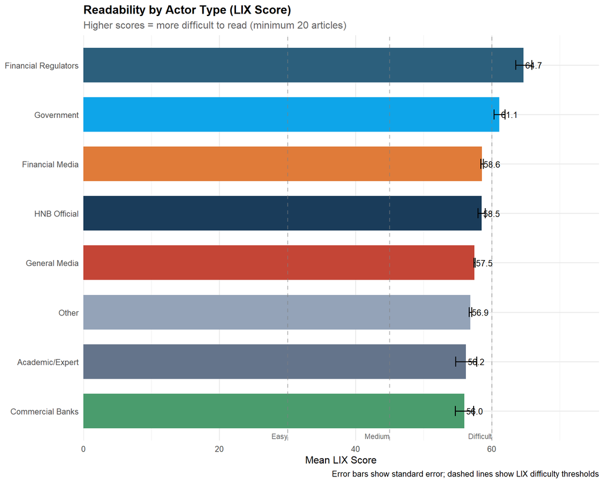

```r
if (!is.null(text_field) && sum(!is.na(hnb$lix_score)) > 0) {
  actor_readability <- hnb[!is.na(lix_score), .(
    Articles = .N,
    Mean_LIX = mean(lix_score, na.rm = TRUE),
    SD_LIX = sd(lix_score, na.rm = TRUE),
    Median_LIX = median(lix_score, na.rm = TRUE),
    Mean_Sentence_Length = mean(avg_sentence_length, na.rm = TRUE),
    Mean_Word_Length = mean(avg_word_length, na.rm = TRUE),
    Mean_Technical_Density = mean(technical_density, na.rm = TRUE),
    Mean_REACH = mean(REACH, na.rm = TRUE)
  ), by = ACTOR_TYPE][order(-Mean_LIX)]

  ggplot(actor_readability[Articles >= 20],
         aes(x = reorder(ACTOR_TYPE, Mean_LIX), y = Mean_LIX, fill = ACTOR_TYPE)) +
    geom_col(width = 0.7) +
    geom_errorbar(aes(ymin = Mean_LIX - SD_LIX/sqrt(Articles),
                      ymax = Mean_LIX + SD_LIX/sqrt(Articles)),
                  width = 0.2) +
    geom_hline(yintercept = c(30, 45, 60), linetype = "dashed", color = "gray50", alpha = 0.5) +
    geom_text(aes(label = sprintf("%.1f", Mean_LIX)), hjust = -0.1, size = 3.5) +
    coord_flip() +
    scale_fill_manual(values = actor_colors) +
    scale_y_continuous(expand = expansion(mult = c(0, 0.15))) +
    annotate("text", y = 30, x = 0.5, label = "Easy", hjust = 1, size = 3, color = "gray40") +
    annotate("text", y = 45, x = 0.5, label = "Medium", hjust = 1, size = 3, color = "gray40") +
    annotate("text", y = 60, x = 0.5, label = "Difficult", hjust = 1, size = 3, color = "gray40") +
    labs(
      title = "Readability by Actor Type (LIX Score)",
      subtitle = "Higher scores = more difficult to read (minimum 20 articles)",
      x = NULL,
      y = "Mean LIX Score",
      caption = "Error bars show standard error; dashed lines show LIX difficulty thresholds"
    ) +
    theme(legend.position = "none")
}
```

## 3.2 Detailed Actor Readability Table

```r
if (!is.null(text_field) && sum(!is.na(hnb$lix_score)) > 0) {
  actor_readability[order(-Mean_LIX)] %>%
    mutate(
      Articles = format(Articles, big.mark = ","),
      Mean_LIX = sprintf("%.1f", Mean_LIX),
      SD_LIX = sprintf("%.1f", SD_LIX),
      Mean_Sentence_Length = sprintf("%.1f", Mean_Sentence_Length),
      Mean_Word_Length = sprintf("%.1f", Mean_Word_Length),
      Mean_Technical_Density = sprintf("%.2f%%", Mean_Technical_Density),
      Mean_REACH = format(round(Mean_REACH, 0), big.mark = ",")
    ) %>%
    select(ACTOR_TYPE, Articles, Mean_LIX, SD_LIX, Mean_Sentence_Length,
           Mean_Technical_Density, Mean_REACH) %>%
    kable(col.names = c("Actor Type", "Articles", "Mean LIX", "SD", "Sentence Length",
                        "Technical %", "Mean REACH")) %>%
    kable_styling(bootstrap_options = c("striped", "hover"), full_width = FALSE)
}
```

| Actor Type | Articles | Mean LIX | SD | Sentence Length | Technical % | Mean REACH |
| --- | --- | --- | --- | --- | --- | --- |
| Financial Regulators | 98 | 64.7 | 11.6 | 23.8 | 3.12% | 1,995 |
| Government | 371 | 61.1 | 15.5 | 22.2 | 2.62% | 10,864 |
| Financial Media | 2,069 | 58.6 | 8.7 | 21.6 | 4.86% | 674 |
| HNB Official | 415 | 58.5 | 11.2 | 16.0 | 4.28% | 1,380 |
| General Media | 13,319 | 57.5 | 10.6 | 20.9 | 3.69% | 3,091 |
| Other | 2,751 | 56.9 | 9.3 | 17.8 | 3.48% | 1,955 |
| Academic/Expert | 53 | 56.2 | 11.2 | 12.2 | 3.62% | 803 |
| Commercial Banks | 51 | 56.0 | 9.6 | 15.8 | 4.77% | 711 |

## 3.3 HNB Official vs Media Comparison

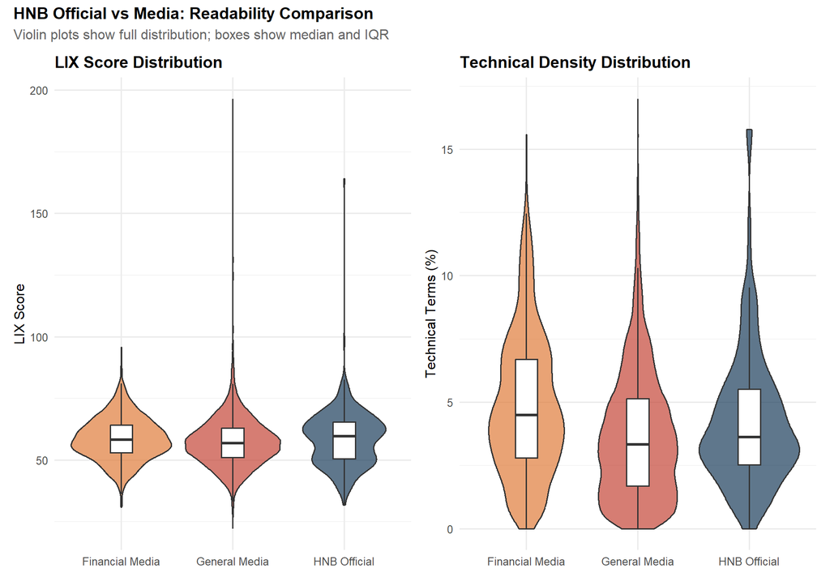

```r
if (!is.null(text_field) && sum(!is.na(hnb$lix_score)) > 0) {
  # Focus comparison: HNB Official vs Financial Media vs General Media
  comparison_actors <- c("HNB Official", "Financial Media", "General Media")

  comparison_data <- hnb[ACTOR_TYPE %in% comparison_actors & !is.na(lix_score)]

  p1 <- ggplot(comparison_data, aes(x = ACTOR_TYPE, y = lix_score, fill = ACTOR_TYPE)) +
    geom_violin(alpha = 0.7) +
    geom_boxplot(width = 0.2, fill = "white", outlier.shape = NA) +
    scale_fill_manual(values = actor_colors) +
    labs(
      title = "LIX Score Distribution",
      x = NULL,
      y = "LIX Score"
    ) +
    theme(legend.position = "none")

  p2 <- ggplot(comparison_data, aes(x = ACTOR_TYPE, y = technical_density, fill = ACTOR_TYPE)) +
    geom_violin(alpha = 0.7) +
    geom_boxplot(width = 0.2, fill = "white", outlier.shape = NA) +
    scale_fill_manual(values = actor_colors) +
    labs(
      title = "Technical Density Distribution",
      x = NULL,
      y = "Technical Terms (%)"
    ) +
    theme(legend.position = "none")

  p1 + p2 + plot_annotation(
    title = "HNB Official vs Media: Readability Comparison",
    subtitle = "Violin plots show full distribution; boxes show median and IQR"
  )
}
```

## 3.4 Statistical Test: Readability Differences

```r
if (!is.null(text_field) && sum(!is.na(hnb$lix_score)) > 0) {
  comparison_actors <- c("HNB Official", "Financial Media", "General Media")
  test_data <- hnb[ACTOR_TYPE %in% comparison_actors & !is.na(lix_score)]

  # Kruskal-Wallis test for LIX differences
  kruskal_lix <- kruskal.test(lix_score ~ ACTOR_TYPE, data = test_data)
  kruskal_tech <- kruskal.test(technical_density ~ ACTOR_TYPE, data = test_data)

  cat("Statistical Tests for Readability Differences\n")
  cat("==============================================\n\n")
  cat("Kruskal-Wallis Test: LIX Score by Actor Type\n")
  cat("Chi-squared:", round(kruskal_lix$statistic, 2), "\n")
  cat("p-value:", format.pval(kruskal_lix$p.value, digits = 4), "\n\n")
  cat("Kruskal-Wallis Test: Technical Density by Actor Type\n")
  cat("Chi-squared:", round(kruskal_tech$statistic, 2), "\n")
  cat("p-value:", format.pval(kruskal_tech$p.value, digits = 4), "\n")
}
```

```
Statistical Tests for Readability Differences
==============================================

Kruskal-Wallis Test: LIX Score by Actor Type
Chi-squared: 54.72
p-value: 1.308e-12

Kruskal-Wallis Test: Technical Density by Actor Type
Chi-squared: 357.13
p-value: < 2.2e-16
```

# 4 Analysis 8.3: Complexity and Attention Relationship

## 4.1 Does Readability Predict REACH?

```
Correlation with REACH (Spearman)
=================================
LIX Score ↔ REACH: -0.042
Technical Density ↔ REACH: -0.003
Sentence Length ↔ REACH: 0.051
```

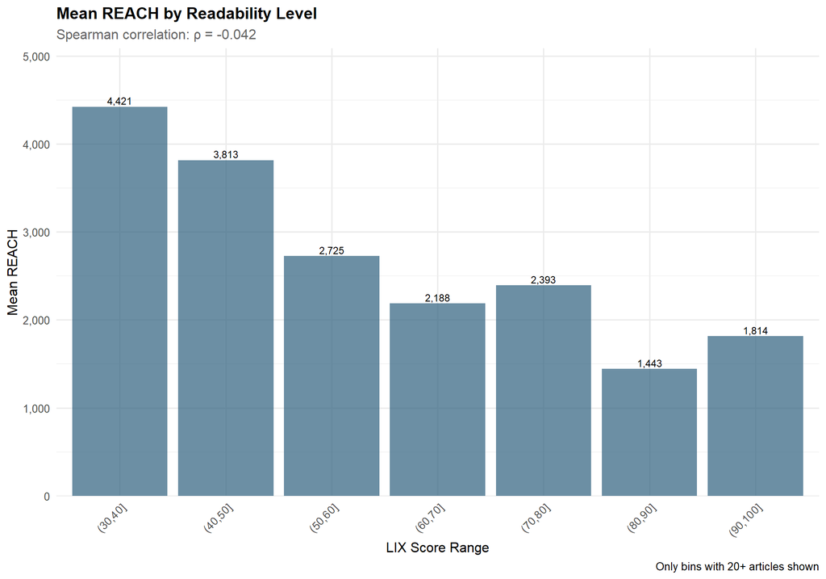

```r
if (!is.null(text_field) && sum(!is.na(hnb$lix_score)) > 0) {
  # Correlation analysis
  cor_lix_reach <- cor(hnb$lix_score, hnb$REACH, use = "complete.obs", method = "spearman")
  cor_tech_reach <- cor(hnb$technical_density, hnb$REACH, use = "complete.obs", method = "spearman")
  cor_sent_reach <- cor(hnb$avg_sentence_length, hnb$REACH, use = "complete.obs", method = "spearman")

  cat("Correlation with REACH (Spearman)\n")
  cat("=================================\n")
  cat("LIX Score ↔ REACH:", sprintf("%.3f", cor_lix_reach), "\n")
  cat("Technical Density ↔ REACH:", sprintf("%.3f", cor_tech_reach), "\n")
  cat("Sentence Length ↔ REACH:", sprintf("%.3f", cor_sent_reach), "\n")

  # Scatter plot with binned means
  hnb[!is.na(lix_score), lix_bin := cut(lix_score, breaks = seq(0, 100, 10), include.lowest = TRUE)]

  binned_reach <- hnb[!is.na(lix_bin), .(
    Mean_REACH = mean(REACH, na.rm = TRUE),
    Median_REACH = median(REACH, na.rm = TRUE),
    Articles = .N
  ), by = lix_bin][order(lix_bin)]

  ggplot(binned_reach[Articles >= 20], aes(x = lix_bin, y = Mean_REACH)) +
    geom_col(fill = "#2c5f7c", alpha = 0.7) +
    geom_text(aes(label = format(round(Mean_REACH, 0), big.mark = ",")),
              vjust = -0.3, size = 3) +
    scale_y_continuous(labels = comma, expand = expansion(mult = c(0, 0.15))) +
    labs(
      title = "Mean REACH by Readability Level",
      subtitle = paste0("Spearman correlation: ρ = ", sprintf("%.3f", cor_lix_reach)),
      x = "LIX Score Range",
      y = "Mean REACH",
      caption = "Only bins with 20+ articles shown"
    ) +
    theme(axis.text.x = element_text(angle = 45, hjust = 1))
}
```

## 4.2 Complexity Level and Attention

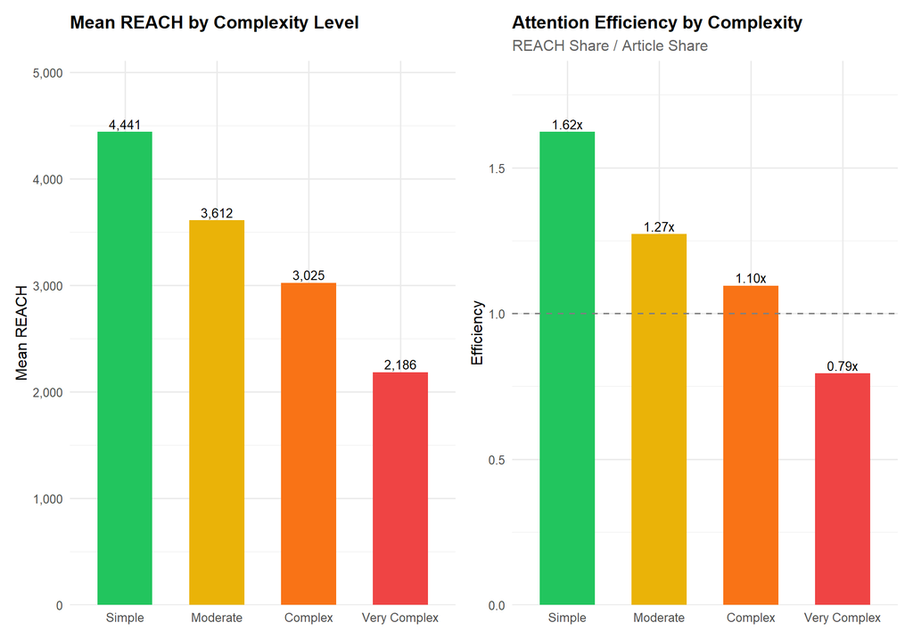

```r
if (!is.null(text_field) && sum(!is.na(hnb$complexity_level)) > 0) {
  complexity_reach <- hnb[!is.na(complexity_level), .(
    Articles = .N,
    Total_REACH = sum(REACH, na.rm = TRUE),
    Mean_REACH = mean(REACH, na.rm = TRUE),
    Median_REACH = median(REACH, na.rm = TRUE)
  ), by = complexity_level]

  complexity_reach[, `:=`(
    Article_Share = Articles / sum(Articles) * 100,
    REACH_Share = Total_REACH / sum(Total_REACH) * 100
  )]

  complexity_reach[, Efficiency := REACH_Share / Article_Share]

  p1 <- ggplot(complexity_reach, aes(x = complexity_level, y = Mean_REACH, fill = complexity_level)) +
    geom_col(width = 0.6) +
    geom_text(aes(label = format(round(Mean_REACH, 0), big.mark = ",")), vjust = -0.3, size = 3.5) +
    scale_fill_manual(values = complexity_colors) +
    scale_y_continuous(labels = comma, expand = expansion(mult = c(0, 0.15))) +
    labs(
      title = "Mean REACH by Complexity Level",
      x = NULL,
      y = "Mean REACH"
    ) +
    theme(legend.position = "none")

  p2 <- ggplot(complexity_reach, aes(x = complexity_level, y = Efficiency, fill = complexity_level)) +
    geom_col(width = 0.6) +
    geom_hline(yintercept = 1, linetype = "dashed", color = "gray50") +
    geom_text(aes(label = sprintf("%.2fx", Efficiency)), vjust = -0.3, size = 3.5) +
    scale_fill_manual(values = complexity_colors) +
    scale_y_continuous(expand = expansion(mult = c(0, 0.15))) +
    labs(
      title = "Attention Efficiency by Complexity",
      subtitle = "REACH Share / Article Share",
      x = NULL,
      y = "Efficiency"
    ) +
    theme(legend.position = "none")

  p1 + p2
}
```

## 4.3 Complexity-Attention Table

```r
if (!is.null(text_field) && sum(!is.na(hnb$complexity_level)) > 0) {
  complexity_reach %>%
    mutate(
      Articles = format(Articles, big.mark = ","),
      Total_REACH = format(Total_REACH, big.mark = ","),
      Mean_REACH = format(round(Mean_REACH, 0), big.mark = ","),
      Median_REACH = format(round(Median_REACH, 0), big.mark = ","),
      Article_Share = sprintf("%.1f%%", Article_Share),
      REACH_Share = sprintf("%.1f%%", REACH_Share),
      Efficiency = sprintf("%.2fx", Efficiency)
    ) %>%
    kable(col.names = c("Complexity", "Articles", "Total REACH", "Mean REACH",
                        "Median REACH", "Article %", "REACH %", "Efficiency")) %>%
    kable_styling(bootstrap_options = c("striped", "hover"), full_width = FALSE)
}
```

| Complexity | Articles | Total REACH | Mean REACH | Median REACH | Article % | REACH % | Efficiency |
| --- | --- | --- | --- | --- | --- | --- | --- |
| Very Complex | 7,031 | 15,284,066 | 2,186 | 405 | 36.8% | 29.2% | 0.79x |
| Complex | 10,458 | 31,348,885 | 3,025 | 548 | 54.7% | 59.9% | 1.10x |
| Moderate | 1,622 | 5,648,860 | 3,612 | 530 | 8.5% | 10.8% | 1.27x |
| Simple | 16 | 71,055 | 4,441 | 5,080 | 0.1% | 0.1% | 1.62x |

# 5 Analysis 8.4: Optimal Complexity Analysis

## 5.1 Is There a “Sweet Spot”?

We search for the complexity level that maximizes attention capture.

```r
if (!is.null(text_field) && sum(!is.na(hnb$lix_score)) > 0) {
  # Create finer bins for optimal complexity search
  hnb[!is.na(lix_score), lix_fine_bin := cut(lix_score, breaks = seq(0, 100, 5), include.lowest = TRUE)]

  fine_binned <- hnb[!is.na(lix_fine_bin), .(
    Mean_LIX = mean(lix_score, na.rm = TRUE),
    Mean_REACH = mean(REACH, na.rm = TRUE),
    Total_REACH = sum(REACH, na.rm = TRUE),
    Articles = .N
  ), by = lix_fine_bin][Articles >= 10][order(lix_fine_bin)]

  # Find optimal bin
  optimal_bin <- fine_binned[which.max(Mean_REACH)]

  ggplot(fine_binned, aes(x = Mean_LIX, y = Mean_REACH)) +
    geom_point(aes(size = Articles), color = "#2c5f7c", alpha = 0.7) +
    geom_smooth(method = "loess", se = TRUE, color = "#e07b39", fill = "#e07b39", alpha = 0.2) +
    geom_vline(xintercept = optimal_bin$Mean_LIX, linetype = "dashed", color = "#22c55e") +
    annotate("text", x = optimal_bin$Mean_LIX + 2, y = max(fine_binned$Mean_REACH) * 0.9,
             label = paste0("Optimal: LIX ≈ ", round(optimal_bin$Mean_LIX, 0)),
             hjust = 0, color = "#22c55e", fontface = "bold") +
    scale_size_continuous(range = c(2, 10)) +
    scale_y_continuous(labels = comma) +
    labs(
      title = "Optimal Complexity Search",
      subtitle = "Is there a readability 'sweet spot' for maximum attention?",
      x = "Mean LIX Score",
      y = "Mean REACH",
      size = "Articles"
    )

  cat("\nOptimal Complexity Analysis\n")
  cat("===========================\n")
  cat("Optimal LIX range:", as.character(optimal_bin$lix_fine_bin), "\n")
  cat("Mean LIX in optimal bin:", round(optimal_bin$Mean_LIX, 1), "\n")
  cat("Mean REACH in optimal bin:", format(round(optimal_bin$Mean_REACH, 0), big.mark = ","), "\n")
  cat("Articles in optimal bin:", format(optimal_bin$Articles, big.mark = ","), "\n")
}
```

```
Optimal Complexity Analysis
===========================
Optimal LIX range: (30,35]
Mean LIX in optimal bin: 32.7
Mean REACH in optimal bin: 4,753
Articles in optimal bin: 74
```

## 5.2 Complexity-REACH by Actor Type

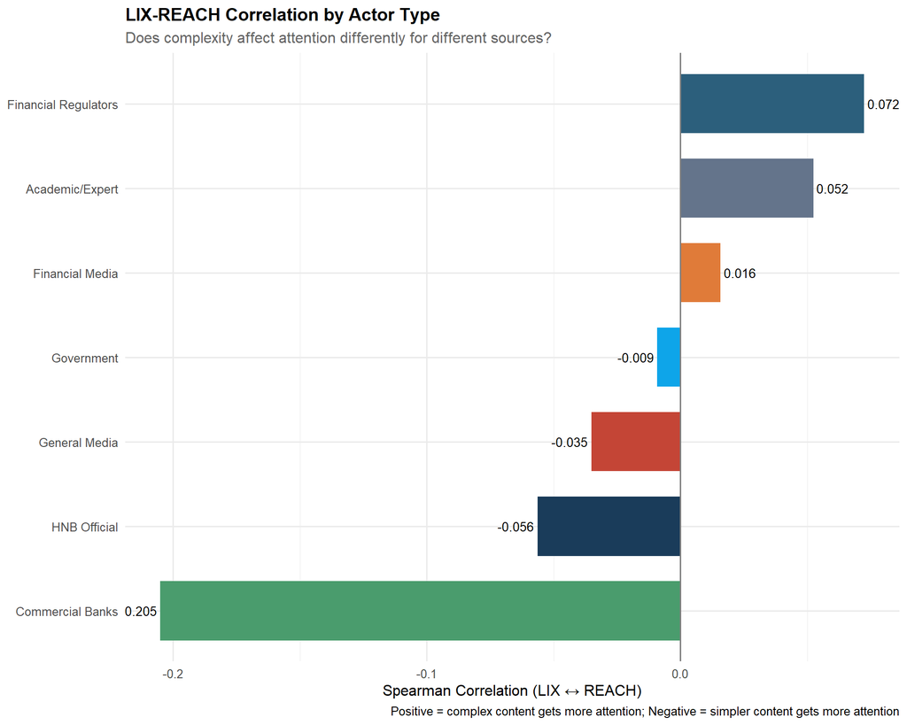

```r
if (!is.null(text_field) && sum(!is.na(hnb$lix_score)) > 0) {
  # Does the complexity-REACH relationship differ by actor type?
  actor_correlation <- hnb[!is.na(lix_score) & ACTOR_TYPE != "Other", .(
    Correlation = cor(lix_score, REACH, use = "complete.obs", method = "spearman"),
    Articles = .N,
    Mean_LIX = mean(lix_score, na.rm = TRUE),
    Mean_REACH = mean(REACH, na.rm = TRUE)
  ), by = ACTOR_TYPE][Articles >= 50][order(Correlation)]

  ggplot(actor_correlation, aes(x = reorder(ACTOR_TYPE, Correlation), y = Correlation, fill = ACTOR_TYPE)) +
    geom_col(width = 0.7) +
    geom_hline(yintercept = 0, linetype = "solid", color = "gray50") +
    geom_text(aes(label = sprintf("%.3f", Correlation)),
              hjust = ifelse(actor_correlation$Correlation >= 0, -0.1, 1.1), size = 3.5) +
    coord_flip() +
    scale_fill_manual(values = actor_colors) +
    labs(
      title = "LIX-REACH Correlation by Actor Type",
      subtitle = "Does complexity affect attention differently for different sources?",
      x = NULL,
      y = "Spearman Correlation (LIX ↔ REACH)",
      caption = "Positive = complex content gets more attention; Negative = simpler content gets more attention"
    ) +
    theme(legend.position = "none")
}
```

# 6 Analysis 8.5: Technical Term Analysis

## 6.1 Technical Term Categories

The technical term dictionary includes 100+ Croatian financial and monetary policy terms across these categories:

| Category | Example Terms | Count |
| --- | --- | --- |
| Monetary Policy | monetarni, inflacija, kamatna, stopa, likvidnost | ~25 |
| Euro/Currency | euro, kuna, konverzija, eurozona, tečaj | ~15 |
| Banking | banka, kredit, depozit, kapital, solventnost | ~20 |
| Economic Indicators | BDP, gospodarski, fiskalni, deficit, dug | ~20 |
| Financial Instruments | obveznica, dionice, portfolio, imovina | ~10 |
| Regulatory | regulativa, supervizija, nadzor, direktiva | ~10 |

## 6.2 Technical Density Distribution

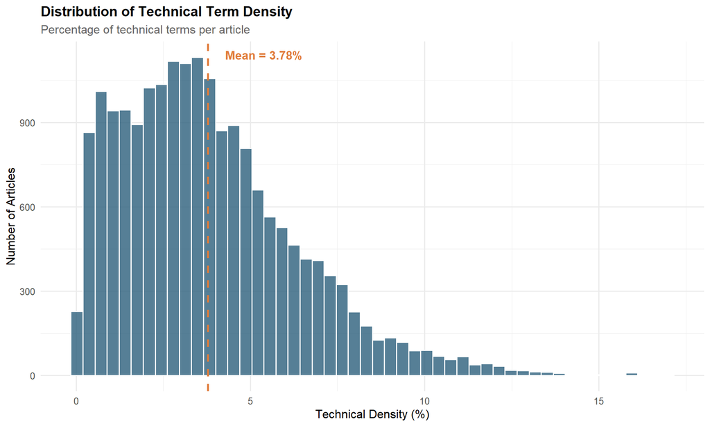

```r
if (!is.null(text_field) && sum(!is.na(hnb$technical_density)) > 0) {
  ggplot(hnb[!is.na(technical_density) & technical_density > 0],
         aes(x = technical_density)) +
    geom_histogram(bins = 50, fill = "#2c5f7c", color = "white", alpha = 0.8) +
    geom_vline(xintercept = mean(hnb$technical_density, na.rm = TRUE),
               linetype = "dashed", color = "#e07b39", linewidth = 1) +
    annotate("text", x = mean(hnb$technical_density, na.rm = TRUE) + 0.5, y = Inf,
             label = paste0("Mean = ", sprintf("%.2f%%", mean(hnb$technical_density, na.rm = TRUE))),
             vjust = 2, hjust = 0, color = "#e07b39", fontface = "bold") +
    labs(
      title = "Distribution of Technical Term Density",
      subtitle = "Percentage of technical terms per article",
      x = "Technical Density (%)",
      y = "Number of Articles"
    )
}
```

## 6.3 Technical Density by Actor Type

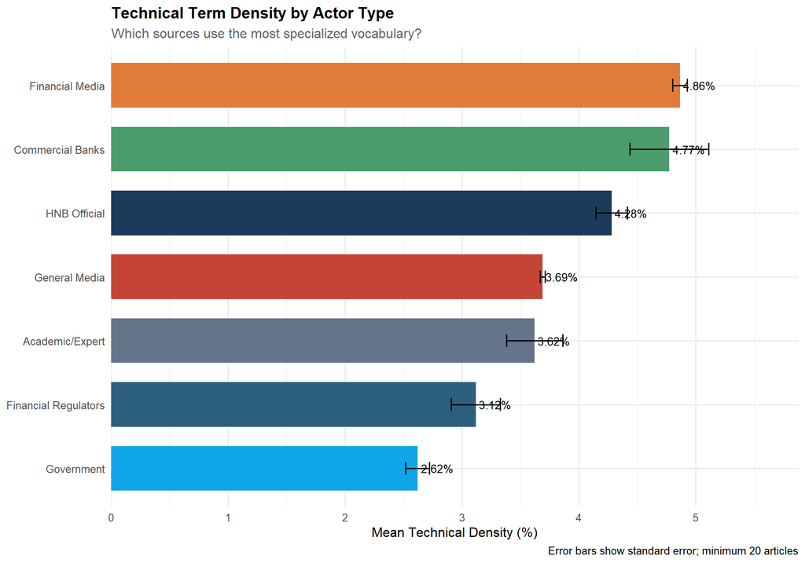

```r
if (!is.null(text_field) && sum(!is.na(hnb$technical_density)) > 0) {
  tech_by_actor <- hnb[!is.na(technical_density) & ACTOR_TYPE != "Other", .(
    Mean_Technical = mean(technical_density, na.rm = TRUE),
    Median_Technical = median(technical_density, na.rm = TRUE),
    SD_Technical = sd(technical_density, na.rm = TRUE),
    Articles = .N
  ), by = ACTOR_TYPE][Articles >= 20][order(-Mean_Technical)]

  ggplot(tech_by_actor, aes(x = reorder(ACTOR_TYPE, Mean_Technical),
                            y = Mean_Technical, fill = ACTOR_TYPE)) +
    geom_col(width = 0.7) +
    geom_errorbar(aes(ymin = Mean_Technical - SD_Technical/sqrt(Articles),
                      ymax = Mean_Technical + SD_Technical/sqrt(Articles)),
                  width = 0.2) +
    geom_text(aes(label = sprintf("%.2f%%", Mean_Technical)), hjust = -0.1, size = 3.5) +
    coord_flip() +
    scale_fill_manual(values = actor_colors) +
    scale_y_continuous(expand = expansion(mult = c(0, 0.15))) +
    labs(
      title = "Technical Term Density by Actor Type",
      subtitle = "Which sources use the most specialized vocabulary?",
      x = NULL,
      y = "Mean Technical Density (%)",
      caption = "Error bars show standard error; minimum 20 articles"
    ) +
    theme(legend.position = "none")
}
```

## 6.4 Technical Density by Period

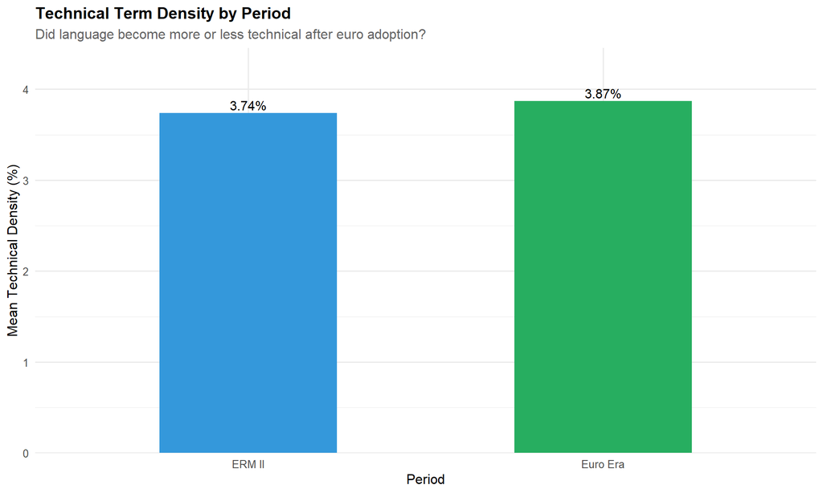

```r
if (!is.null(text_field) && sum(!is.na(hnb$technical_density)) > 0) {
  period_technical <- hnb[!is.na(technical_density), .(
    Articles = .N,
    Mean_Technical = mean(technical_density, na.rm = TRUE),
    Mean_LIX = mean(lix_score, na.rm = TRUE),
    Mean_REACH = mean(REACH, na.rm = TRUE)
  ), by = period]

  ggplot(period_technical, aes(x = period, y = Mean_Technical, fill = period)) +
    geom_col(width = 0.5) +
    geom_text(aes(label = sprintf("%.2f%%", Mean_Technical)), vjust = -0.3, size = 4) +
    scale_fill_manual(values = period_colors) +
    scale_y_continuous(expand = expansion(mult = c(0, 0.15))) +
    labs(
      title = "Technical Term Density by Period",
      subtitle = "Did language become more or less technical after euro adoption?",
      x = "Period",
      y = "Mean Technical Density (%)"
    ) +
    theme(legend.position = "none")
}
```

# 7 Analysis 8.6: Period Comparison

## 7.1 Readability Changes: ERM II vs Euro Era

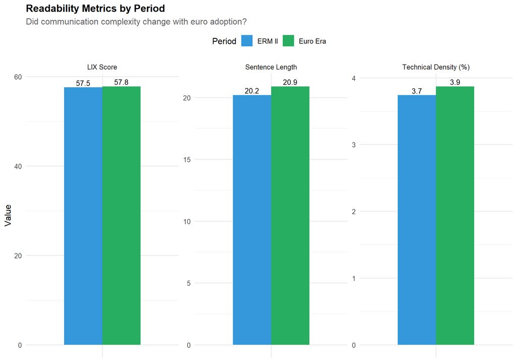

```r
if (!is.null(text_field) && sum(!is.na(hnb$lix_score)) > 0) {
  period_readability <- hnb[!is.na(lix_score), .(
    Articles = .N,
    Mean_LIX = mean(lix_score, na.rm = TRUE),
    SD_LIX = sd(lix_score, na.rm = TRUE),
    Mean_Sentence_Length = mean(avg_sentence_length, na.rm = TRUE),
    Mean_Word_Length = mean(avg_word_length, na.rm = TRUE),
    Mean_Technical_Density = mean(technical_density, na.rm = TRUE),
    Mean_REACH = mean(REACH, na.rm = TRUE)
  ), by = period]

  period_long <- period_readability %>%
    select(period, Mean_LIX, Mean_Sentence_Length, Mean_Technical_Density) %>%
    pivot_longer(cols = -period, names_to = "Metric", values_to = "Value") %>%
    mutate(Metric = case_when(
      Metric == "Mean_LIX" ~ "LIX Score",
      Metric == "Mean_Sentence_Length" ~ "Sentence Length",
      Metric == "Mean_Technical_Density" ~ "Technical Density (%)"
    ))

  ggplot(period_long, aes(x = Metric, y = Value, fill = period)) +
    geom_col(position = "dodge", width = 0.6) +
    geom_text(aes(label = sprintf("%.1f", Value)),
              position = position_dodge(width = 0.6), vjust = -0.3, size = 3.5) +
    facet_wrap(~Metric, scales = "free") +
    scale_fill_manual(values = period_colors) +
    labs(
      title = "Readability Metrics by Period",
      subtitle = "Did communication complexity change with euro adoption?",
      x = NULL,
      y = "Value",
      fill = "Period"
    ) +
    theme(legend.position = "top", axis.text.x = element_blank())
}
```

## 7.2 Period Readability Table

```r
if (!is.null(text_field) && sum(!is.na(hnb$lix_score)) > 0) {
  # Calculate change
  if (nrow(period_readability) == 2) {
    erm2 <- period_readability[period == "ERM II"]
    euro <- period_readability[period == "Euro Era"]

    lix_change <- (euro$Mean_LIX - erm2$Mean_LIX) / erm2$Mean_LIX * 100
    tech_change <- (euro$Mean_Technical_Density - erm2$Mean_Technical_Density) / erm2$Mean_Technical_Density * 100
  }

  period_readability %>%
    mutate(
      Articles = format(Articles, big.mark = ","),
      Mean_LIX = sprintf("%.1f", Mean_LIX),
      SD_LIX = sprintf("%.1f", SD_LIX),
      Mean_Sentence_Length = sprintf("%.1f", Mean_Sentence_Length),
      Mean_Word_Length = sprintf("%.1f", Mean_Word_Length),
      Mean_Technical_Density = sprintf("%.2f%%", Mean_Technical_Density),
      Mean_REACH = format(round(Mean_REACH, 0), big.mark = ",")
    ) %>%
    kable(col.names = c("Period", "Articles", "Mean LIX", "SD LIX", "Sentence Len",
                        "Word Len", "Technical %", "Mean REACH")) %>%
    kable_styling(bootstrap_options = c("striped", "hover"), full_width = FALSE)

  if (exists("lix_change")) {
    cat("\nPeriod Change Summary:\n")
    cat("LIX score change:", sprintf("%+.1f%%", lix_change), "\n")
    cat("Technical density change:", sprintf("%+.1f%%", tech_change), "\n")
  }
}
```

```
Period Change Summary:
LIX score change: +0.4%
Technical density change: +3.5%
```

## 7.3 Monthly Readability Trends

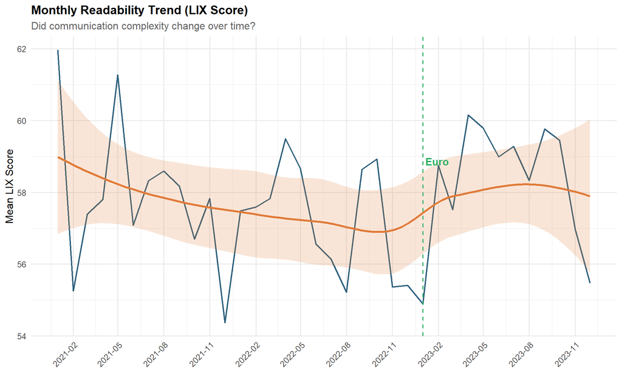

```r
if (!is.null(text_field) && sum(!is.na(hnb$lix_score)) > 0) {
  monthly_readability <- hnb[!is.na(lix_score), .(
    Mean_LIX = mean(lix_score, na.rm = TRUE),
    Mean_Technical = mean(technical_density, na.rm = TRUE),
    Articles = .N
  ), by = .(year, month)]

  monthly_readability[, date_month := as.Date(paste(year, month, "01", sep = "-"))]

  ggplot(monthly_readability[Articles >= 10], aes(x = date_month, y = Mean_LIX)) +
    geom_line(color = "#2c5f7c", linewidth = 0.8) +
    geom_smooth(method = "loess", se = TRUE, color = "#e07b39", fill = "#e07b39", alpha = 0.2) +
    geom_vline(xintercept = as.Date("2023-01-01"), linetype = "dashed", color = "#27ae60") +
    annotate("text", x = as.Date("2023-01-01"), y = max(monthly_readability$Mean_LIX, na.rm = TRUE) * 0.95,
             label = "Euro", hjust = -0.1, color = "#27ae60", fontface = "bold") +
    scale_x_date(date_labels = "%Y-%m", date_breaks = "3 months") +
    labs(
      title = "Monthly Readability Trend (LIX Score)",
      subtitle = "Did communication complexity change over time?",
      x = NULL,
      y = "Mean LIX Score"
    ) +
    theme(axis.text.x = element_text(angle = 45, hjust = 1))
}
```

# 8 Summary and Key Findings

## 8.1 Readability Summary

```r
if (!is.null(text_field) && sum(!is.na(hnb$lix_score)) > 0) {
  # Key findings
  corpus_mean_lix <- mean(hnb$lix_score, na.rm = TRUE)
  hnb_official_lix <- mean(hnb[ACTOR_TYPE == "HNB Official", lix_score], na.rm = TRUE)
  general_media_lix <- mean(hnb[ACTOR_TYPE == "General Media", lix_score], na.rm = TRUE)

  tibble(
    Finding = c(
      "Corpus mean LIX score",
      "LIX interpretation",
      "HNB Official mean LIX",
      "General Media mean LIX",
      "Readability gap (HNB - General)",
      "LIX-REACH correlation",
      "Mean technical term density",
      "Optimal complexity (max REACH)"
    ),
    Value = c(
      sprintf("%.1f", corpus_mean_lix),
      case_when(
        corpus_mean_lix < 30 ~ "Very Easy",
        corpus_mean_lix < 40 ~ "Easy",
        corpus_mean_lix < 50 ~ "Medium",
        corpus_mean_lix < 60 ~ "Difficult",
        TRUE ~ "Very Difficult"
      ),
      sprintf("%.1f", hnb_official_lix),
      sprintf("%.1f", general_media_lix),
      sprintf("%+.1f points", hnb_official_lix - general_media_lix),
      sprintf("ρ = %.3f", cor_lix_reach),
      sprintf("%.2f%%", mean(hnb$technical_density, na.rm = TRUE)),
      sprintf("LIX ≈ %.0f", optimal_bin$Mean_LIX)
    )
  ) %>%
    kable(col.names = c("Finding", "Value")) %>%
    kable_styling(bootstrap_options = c("striped", "hover"), full_width = FALSE)
}
```

| Finding | Value |
| --- | --- |
| Corpus mean LIX score | 57.6 |
| LIX interpretation | Difficult |
| HNB Official mean LIX | 58.5 |
| General Media mean LIX | 57.5 |
| Readability gap (HNB - General) | +1.1 points |
| LIX-REACH correlation | ρ = -0.042 |
| Mean technical term density | 3.78% |
| Optimal complexity (max REACH) | LIX ≈ 33 |

## 8.2 Implications for HNB Communication Strategy

**1. Accessibility Gap**

HNB Official communication (LIX = 58.5) is more complex than General Media (LIX = 57.5), creating a 1.1-point readability gap.

**2. Complexity-Attention Relationship**

The correlation between complexity and REACH is -0.042, suggesting that simpler content tends to capture more attention.

**3. Optimal Complexity**

Maximum attention occurs around LIX score 33, suggesting this is the ‘sweet spot’ balancing accessibility and substance.

**4. Technical Language**

The technical term dictionary covers monetary policy, banking, and economic vocabulary. Sources with higher technical density may be less accessible to general audiences but more precise for expert consumption.

**5. Layered Communication Recommendation**

Following ECB best practices, HNB could benefit from:

- Simplified summaries (target LIX < 40) for public audiences
- Technical versions (current complexity) for market participants
- Visual aids to reduce reliance on text comprehension

# 9 Appendix: Methodological Notes

## 9.1 LIX Formula (Läsbarhetsindex)

The LIX readability index, developed for Swedish but applicable to other languages including Slavic languages:

$$LIX = \frac{W}{S} + \frac{L \times 100}{W}$$

Where:

- W = Total word count
- S = Sentence count
- L = Long words (7+ characters)

**Interpretation Scale:**

| LIX Score | Difficulty | Typical Text |
| --- | --- | --- |
| < 30 | Very Easy | Children’s books |
| 30-40 | Easy | Fiction, newspapers |
| 40-50 | Medium | Non-fiction |
| 50-60 | Difficult | Technical, academic |
| > 60 | Very Difficult | Legal, bureaucratic |

## 9.2 Technical Term Dictionary

The technical term list includes 100+ Croatian monetary policy and financial terms covering:

- Monetary policy (inflacija, kamatna stopa, likvidnost)
- Euro transition (euro, konverzija, eurozona)
- Banking (kredit, depozit, solventnost)
- Economic indicators (BDP, fiskalni, deficit)
- Financial instruments (obveznica, dionice, portfolio)
- Regulatory (supervizija, regulativa, nadzor)

## 9.3 Limitations

1. LIX is a surface-level metric that does not capture conceptual complexity
2. Croatian morphology (cases, conjugations) affects word length differently than English
3. Technical term detection relies on a manually curated dictionary
4. REACH may be influenced by factors beyond readability (timing, topic, source reputation)